# Visualising and Analysing Time-oriented Data with R

Putting Visual Analytics into Practical Use

Min Xiaoqi https://www.linkedin.com/in/xiaoqi-min/ (Master of IT in Business, Singapore Management University)https://scis.smu.edu.sg/master-it-business/financial-technology-and-analytics-track  
2022-02-26

# Getting started

We will install and launch the following R packages:

```r
packages =c('scales','viridis','lubridate','ggthemes','gridExtra','tidyverse','readxl','knitr','data.table','dplyr')
for(p in packages){library
  if(!require(p, character.only = T)){
    install.packages(p)
  }
  library(p, character.only = T)
}
```

# Calendar Heatmap

## Import data

```r
attacks <- read_csv("data/eventlog.csv")
```

## Examining the data structure

*kable()* can be used to review the structure of the imported data frame

```r
kable(head(attacks))
```

| timestamp | source_country | tz |
| --- | --- | --- |
| 2015-03-12 15:59:16 | CN | Asia/Shanghai |
| 2015-03-12 16:00:48 | FR | Europe/Paris |
| 2015-03-12 16:02:26 | CN | Asia/Shanghai |
| 2015-03-12 16:02:38 | US | America/Chicago |
| 2015-03-12 16:03:22 | CN | Asia/Shanghai |
| 2015-03-12 16:03:45 | CN | Asia/Shanghai |

## Deriving the day of the week and hour of the day variables

A quick exploratory data analysis on this attacker data is what were the “working hours” by country, and we can visualize this with a calendar heatmap. To create the heatmap, we’ll need the weekday and hour of each event, or as granular as you want to get.

The function below converts each time with the appropriate timezone, the timezone parameter, tz, only takes a single value, then extract its weekdays and hour

```r
make_hr_wkday <- function(ts, sc, tz) {
  real_times <- ymd_hms(ts,
                        tz = tz[1],
                        quiet = TRUE)
  dt <- data.table(source_country = sc,
                   wkday = weekdays(real_times),
                   hour = hour(real_times))
  return(dt)
}
```

## Converting weekday and hour into factor so they’ll be ordered when plotting

```r
wkday_levels <- c('Sunday', 'Monday',
                  'Tuesday', 'Wednesday',
                  'Thursday', 'Friday',
                  'Saturday')
attacks <- attacks %>%
  group_by(tz) %>%
  do(make_hr_wkday(.$timestamp,
                   .$source_country,
                   .$tz ) ) %>%
  ungroup() %>%
  mutate(wkday = factor(wkday,
                        levels = wkday_levels),
         hour  = factor(hour,
                        levels = 0:23))
```

## The calendar heatmaps

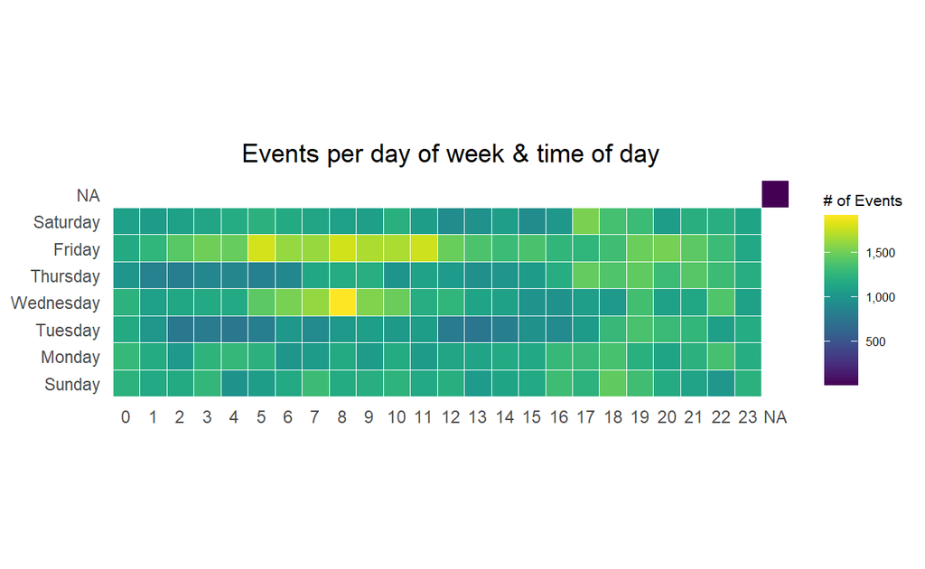

```r
grouped <- attacks %>%
  count(wkday, hour) %>%
  ungroup()
ggplot(grouped,
       aes(hour,
           wkday,
           fill = n)) +
geom_tile(color = "white",
          size = 0.1) +
theme_tufte(base_family = "Helvetica") +
coord_equal() +
scale_fill_viridis(name = "# of Events",
                   label = comma) +
labs(x = NULL,
     y = NULL,
     title = "Events per day of week & time of day") +
theme(axis.ticks = element_blank(),
      plot.title = element_text(hjust = 0.5),
      legend.title = element_text(size = 8),
      legend.text = element_text(size = 6) )
```

# Cycle Plot

## Data import

The code chunk below imports arrivals_by_air.xlsx by using *read_excel()* of **readxl** packag and save it as a tibble data frame called air.

```r
air <- read_excel("data/arrivals_by_air.xlsx")
```

## Deriving month and year fields

Next, two new fields called month and year are derived from Month-Year field.

```r
air$month <- factor(month(air$`Month-Year`),
                    levels=1:12,
                    labels=month.abb,
                    ordered=TRUE)
air$year <- year(ymd(air$`Month-Year`))
```

## Extracting the target country

```r
New_Zealand <- air %>%
  select(`New Zealand`,
         month,
         year) %>%
  filter(year >= 2010)
```

## Computing year average arrivals by month

The code chunk below uses *group-by()* and *summarise()* of **dplyr** to compute year average arrivals by month.

```r
hline.data <- New_Zealand %>%
  group_by(month) %>%
  summarise(avgvalue = mean(`New Zealand`)) %>%
  ungroup()
```

## Plotting the cycle plot

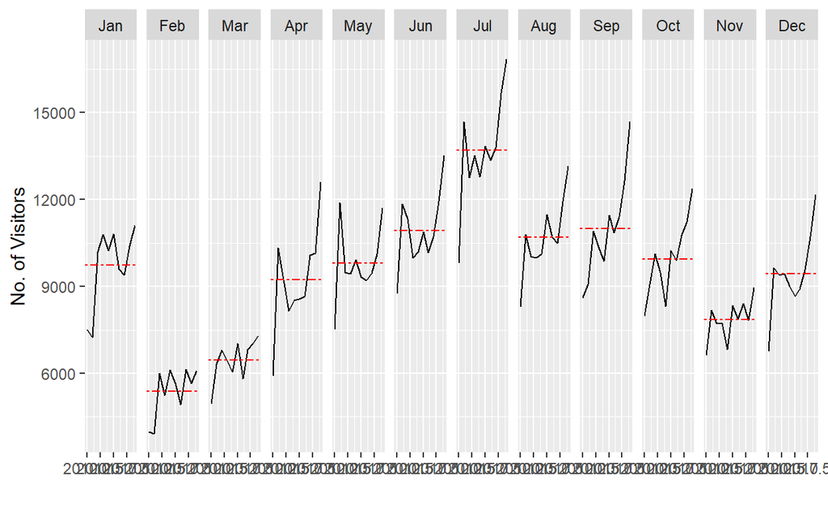

```r
ggplot() +
  geom_line(data=New_Zealand,
            aes(x=year,
                y=`New Zealand`,
                group=month),
            colour="black") +
  geom_hline(aes(yintercept=avgvalue),
             data=hline.data,
             linetype=6,
             colour="red",
             size=0.5) +
  facet_grid(~month) +
  labs(axis.text.x = element_blank()) +
  xlab("") +
  ylab("No. of Visitors")
```